# Transcriptomics data integration and batch correction

**Authors**: *Momeneh (Sepideh) Foroutan* and *Ramyar Molania*

In this document, we intergrate normalised data from 10 microarray studies, assess the presence of unwanted variations in the integrated data, and show you different methods for removing batch effects for obtaining DEGs between the control and TGFb-treated samples. These methods include limma, ComBat, SVA and RUVs.

First, we load the required libraries.

```r
library(limma)          ## for DE analysis
library(sva)            ## for performing ComBat and SVA
library(ruv)            ## for performing RUV
library(NMF)            ## for drawing heatmaps
library(matrixStats)
```

Add a sub-directory to save the output of the analysis.

```r
dir.create(file.path(mainPath, "out"), showWarnings = FALSE)
```

[output not shown]

Read in the 10 datasets (this level of data has been obtained in previous session).

```r
d<- read.table("minPval_10data_Deshiere.txt", header=T, sep="\t")
hes<- read.table("minPval_10data_Hesling.txt", header=T, sep="\t")
hil<- read.table("minPval_10data_Hills.txt", header=T, sep="\t")
k<- read.table("minPval_10data_Keshamouni.txt", header=T, sep="\t")
m<- read.table("minPval_10data_Maupin.txt", header=T, sep="\t")
s_A<- read.table("minPval_10data_Sun_A.txt", header=T, sep="\t")
s_HCC<- read.table("minPval_10data_Sun_HCC.txt", header=T, sep="\t")
s_NCI<- read.table("minPval_10data_Sun_NCI.txt", header=T, sep="\t")
t<- read.table("minPval_10data_Taube.txt", header=T, sep="\t")
w<- read.table("minPval_10data_Walsh.txt", header=T, sep="\t")
```

For this part of the analysis, we only need the expression values not the test statistics. So, we subset each dataset and change the columns to have more meaningful column names.

```r
# names(d)
good_cols<- grep(("Entrez|_R"), colnames(d) )
d<- d[,good_cols]
# head(d)
colnames(d)<- c("D_Ctrl_R1", "D_TGFb_R1","D_Ctrl_R2", "D_TGFb_R2", "EntrezID" )
good_cols<- grep(("Entrez|_R"), colnames(hes) )
hes<- hes[,good_cols]
colnames(hes)<- c("Hes_Ctrl_R1", "Hes_TGFb_R1", "Hes_Ctrl_R2", "Hes_TGFb_R2", "EntrezID")
good_cols<- grep(("Entrez|X"), colnames(hil) )
hil<- hil[,good_cols]
colnames(hil)<- c("Hil_Ctrl_R1", "Hil_Ctrl_R2", "Hil_Ctrl_R3",
                  "Hil_TGFb_R1", "Hil_TGFb_R2", "Hil_TGFb_R3", "EntrezID")
good_cols<- grep(("Entrez|_R"), colnames(k) )
k<- k[, good_cols]
colnames(k)<- c("K_Ctrl_R1", "K_Ctrl_R2", "K_Ctrl_R3",
                "K_TGFb_R1", "K_TGFb_R2", "K_TGFb_R3", "EntrezID")
good_cols<- grep(("Entrez|_R"), colnames(m) )
m<- m[, good_cols]
colnames(m)<- c("M_Ctrl_R1", "M_Ctrl_R2", "M_Ctrl_R3",
                "M_TGFb_R1", "M_TGFb_R2", "M_TGFb_R3", "EntrezID")
good_cols<- grep(("Entrez|.CEL"), colnames(s_A) )
s_A<- s_A[, good_cols]
colnames(s_A)<- c("S_A_Ctrl_R1", "S_A_Ctrl_R2", "S_A_Ctrl_R3",
                  "S_A_TGFb_R1", "S_A_TGFb_R2", "S_A_TGFb_R3", "EntrezID")
good_cols<- grep(("Entrez|.CEL"), colnames(s_HCC) )
s_HCC<- s_HCC[, good_cols]
colnames(s_HCC)<- c("S_HCC_Ctrl_R1", "S_HCC_Ctrl_R2", "S_HCC_Ctrl_R3",
                    "S_HCC_TGFb_R1", "S_HCC_TGFb_R2", "S_HCC_TGFb_R3", "EntrezID")
good_cols<- grep(("Entrez|.CEL"), colnames(s_NCI) )
s_NCI<- s_NCI[, good_cols]
colnames(s_NCI)<- c("S_NCI_Ctrl_R1", "S_NCI_Ctrl_R2", "S_NCI_Ctrl_R3",
                    "S_NCI_TGFb_R1", "S_NCI_TGFb_R2", "S_NCI_TGFb_R3", "EntrezID")
good_cols<- grep(("Entrez|_R"), colnames(t) )
t<- t[, good_cols]
colnames(t)<- c("T_Ctrl1_R1", "T_Ctrl1_R2", "T_Ctrl1_R3",
                "T_TGFb_R1", "T_TGFb_R2", "T_TGFb_R3",
                "T_Ctrl2_R1", "T_Ctrl2_R2", "T_Ctrl2_R3", "EntrezID")
good_cols<- grep(("Entrez|_R"), colnames(w) )
w<- w[, good_cols]
colnames(w)<- c("W_Ctrl_R1", "W_Ctrl_R2", "W_Ctrl_R3",
                "W_TGFb_R1", "W_TGFb_R2", "W_TGFb_R3", "EntrezID")
```

Then, we creat a list containing all the datasets and merge them.

```r
dim(all) #11900  60
```

```
[1] 11900    60
```

Look at the merged data:

```r
# all<- read.table("./out_10data_check/expr_10data.txt", sep="\t", header=T)
head(all, 3)
```

|  | EntrezID | D_Ctrl_R1 | D_TGFb_R1 | D_Ctrl_R2 | D_TGFb_R2 | Hes_Ctrl_R1 | Hes_TGFb_R1 | Hes_Ctrl_R2 | Hes_TGFb_R2 | Hil_Ctrl_R1 | Hil_Ctrl_R2 | Hil_Ctrl_R3 | Hil_TGFb_R1 | Hil_TGFb_R2 | Hil_TGFb_R3 | M_Ctrl_R1 | M_Ctrl_R2 | M_Ctrl_R3 | M_TGFb_R1 | M_TGFb_R2 | M_TGFb_R3 | K_Ctrl_R1 | K_Ctrl_R2 | K_Ctrl_R3 | K_TGFb_R1 | K_TGFb_R2 | K_TGFb_R3 | S_A_Ctrl_R1 | S_A_Ctrl_R2 | … |
| --- | --- | --- | --- | --- | --- | --- | --- | --- | --- | --- | --- | --- | --- | --- | --- | --- | --- | --- | --- | --- | --- | --- | --- | --- | --- | --- | --- | --- | --- | --- |
| 1 | 2 | 4.182898 | 4.234204 | 4.271958 | 4.221931 | 6.212082 | 6.307131 | 6.127601 | 6.147889 | 5.506770 | 5.553145 | 5.479789 | 5.569616 | 5.671409 | 5.573899 | 4.560858 | 4.403457 | 4.319724 | 4.744270 | 4.588234 | 4.584527 | 4.777384 | 4.917127 | 4.858409 | 4.937631 | 5.168482 | 5.194140 | 3.476009 | 3.507338 | … |
| 2 | 9 | 5.763352 | 6.063185 | 5.698005 | 5.856127 | 8.136114 | 8.511206 | 8.454491 | 8.423706 | 6.624455 | 6.918824 | 6.689678 | 6.857544 | 6.844987 | 6.896004 | 4.416877 | 4.319870 | 4.393092 | 4.544959 | 4.458979 | 4.396294 | 7.988627 | 7.962891 | 8.171779 | 8.057742 | 8.042637 | 8.080908 | 7.966643 | 7.958268 | … |
| 3 | 10 | 4.467305 | 4.427406 | 4.403148 | 4.432531 | 4.746120 | 4.690118 | 4.655949 | 4.599947 | 5.634859 | 5.713780 | 5.587489 | 5.643846 | 5.714321 | 5.629158 | 4.093639 | 4.033749 | 4.032735 | 4.023618 | 4.158607 | 4.212378 | 4.998611 | 5.313192 | 4.930239 | 4.887161 | 4.924362 | 4.828075 | 4.245783 | 4.266803 | … |

```r
m<- all[,2:60]
row.names(m)<- all[,1]
m<- as.matrix(m)
```

We creat a data frame containing the information related to each of the samples, including the name of the studies, type of platforms, treatment, and tissue types; we will be using these information later for batch visulaisation and correction.

| samples | study | treatment | platform | tissue |
| --- | --- | --- | --- | --- |
| D_Ctrl_R1 | Deshiere | Ctrl | Agilent | Breast |
| D_TGFb_R1 | Deshiere | TGFb | Agilent | Breast |
| D_Ctrl_R2 | Deshiere | Ctrl | Agilent | Breast |
| D_TGFb_R2 | Deshiere | TGFb | Agilent | Breast |
| Hes_Ctrl_R1 | Hesling | Ctrl | HG_U133_Plus2 | Breast |
| Hes_TGFb_R1 | Hesling | TGFb | HG_U133_Plus2 | Breast |
| Hes_Ctrl_R2 | Hesling | Ctrl | HG_U133_Plus2 | Breast |
| Hes_TGFb_R2 | Hesling | TGFb | HG_U133_Plus2 | Breast |
| Hil_Ctrl_R1 | Hills | Ctrl | Illumina | Kidney |
| Hil_Ctrl_R2 | Hills | Ctrl | Illumina | Kidney |

[output cut: 49 more lines]

## Assessment of unwanted variations in the data.

Here we perform some exploratory analysis on the integrated datato assess the amount of batch (or unwanted variation) on the data.  
We start with RLE plots.

```r
mycols<- c("blue", "cyan", "violet", "dark green", "gold",
           "orangered", "pink", "gray", "light blue", "turquoise",
           "red")
rle<- m-rowMedians(m)
boxplot(rle , col= mycols[as.factor(info$study)] ,
          # ylim=ylim,
          las=2 , cex.axis=1.2 , ylab="RLE" , xlab="Samples" , cex.lab=1.2 ,
          names=FALSE  , frame=F  , whisklty = 1, staplelty = 0 , outline=FALSE )
abline(h=0 , col="darkblue", lwd=2)
```

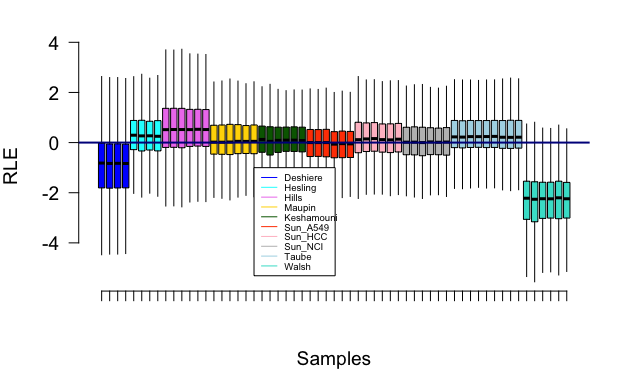

```r
legend(x=20, y=-1, legend=unique(as.factor(info$study)), col= mycols[unique(as.factor(info$study))], lty=1, cex=0.6)
```

```r
boxplot(rle , col= mycols[as.factor(info$platform)] ,
          # ylim=ylim,
          las=2 , cex.axis=1.2 , ylab="RLE" , xlab="Samples" , cex.lab=1.2 ,
          names=FALSE  , frame=F  , whisklty = 1, staplelty = 0 , outline=FALSE )
abline(h=0 , col="darkblue", lwd=2)
```

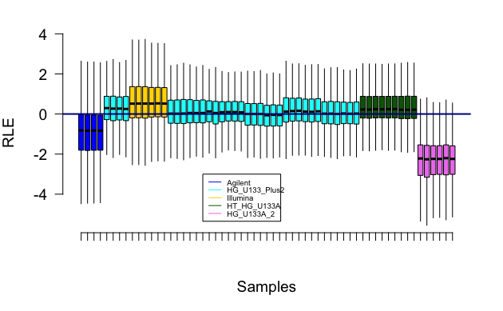

```r
legend(x=20, y=-3, legend=unique(as.factor(info$platform)), col= mycols[unique(as.factor(info$platform))], lty=1, cex=0.6)
```

Assess the presence of batch effects using MDS plots coloured according to batch or biology.

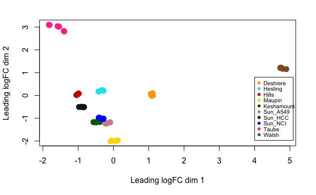

```r
mycols<- c("orange", "turquoise2", "red3", "darkgreen", "gold", "pink3",
           "grey10", "blue", "violetred1", "tan4")
plotMDS(m, col= mycols[as.factor(info$study)], pch=19, cex=1.5)
legend(x=4, y=.8, legend=unique(as.factor(info$study)), col= mycols[unique(as.factor(info$study))], pch=19, cex=0.7)
```

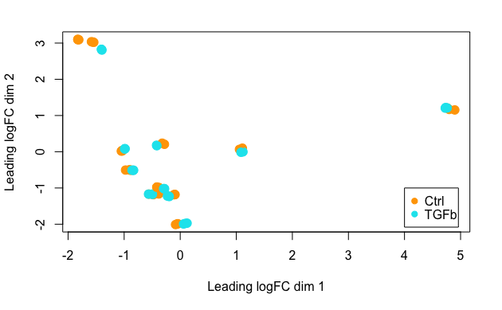

```r
plotMDS(m, col= mycols[as.factor(info$treatment)], pch=19, cex=1.5)
legend(x=4, y=-1, legend=unique(as.factor(info$treatment)), col= mycols[unique(as.factor(info$treatment))], pch=19, cex=1)
```

## Remove bacth effects for obtaining DEGs.

In this section we discuss several ways to remove unwanted variations *when the purpose of study is DE analysis*.  
The first option is to remove batch while we are doing DE analysis using **limma** package. Then we explain about ComBat, SVA and RUVs.  
The batch correction methods used in limma and ComBat are dependent on the “known” batch effects; i.e. you need to know what is the source of unwanted variations (such as different laboratories, different years of running experiments, etc.). However, SVA and RUV methods estimate surrogate variables or unwanted variations and then remove them.  
For the current example, this is really important to note that because in a few cases the platforms and studies are completely confounded, we don’t know for sure how much of the variations come from the study or the platform… these kinds of confounding situations cannot be handeled by any of the methods and must be avoided when designing an experiment. Here, we only consider “study” as the true source of variation.

### Batch correction using limma

The *removeBatchEffect()* function in limma takes the expr matrix, a column for batch, and a column for covariates, if applicable. Note that covariates are different from batches: Batch effects are categorical variables such as locations or platforms, while covariates are numeric values and it takes into account that how large are the values, such as treating a cell with an stimulus for one day vs. six days. Note that here we consider “study” as the resource of unwantd variation, and interestingly, if we add a second batch term into the *removeBatchEffect()* it throws a warning and gives us exactly the same data as without including the second batch term. We use this function **only** for visulaisation purposes, then we show how we remove batch by including the batch term in the design matrix.

```r
identical(cleanDataLimma2, cleanDataLimma)
```

```
[1] TRUE
```

Now look at the RLE and MDS plots after correcting the data.

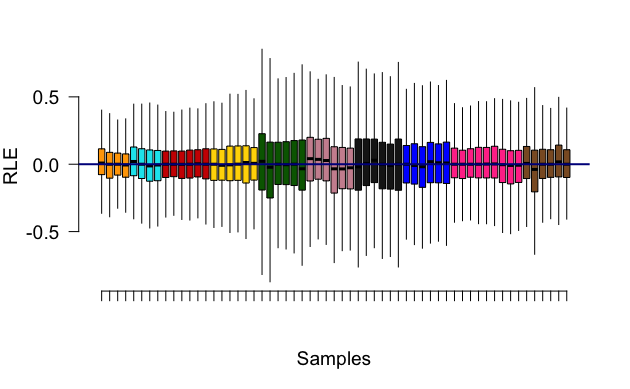

```r
## RLE:
rleLimma<- cleanDataLimma-rowMedians(cleanDataLimma)
boxplot(rleLimma , col= mycols[as.factor(info$study)] ,
          las=2 , cex.axis=1.2 , ylab="RLE" , xlab="Samples" , cex.lab=1.2 ,
          names=FALSE  , frame=F  , whisklty = 1, staplelty = 0 , outline=FALSE )
abline(h=0 , col="darkblue", lwd=2)
```

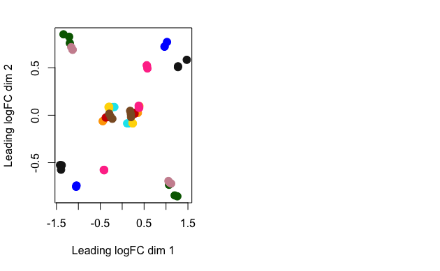

```r
## MDS
par(mfrow=c(1,2))
plotMDS(cleanDataLimma, col= mycols[as.factor(info$study)], pch=19, cex=1.5)
plotMDS(cleanDataLimma, col= mycols[as.factor(info$treatment)], pch=19, cex=1.5)
```

To remove batch effect, we include a term into our design matrix to remove it while performing DE analysis.

```r
groups<- info$treatment
batch<- info$study
designLimma<- model.matrix(~ groups + batch)
```

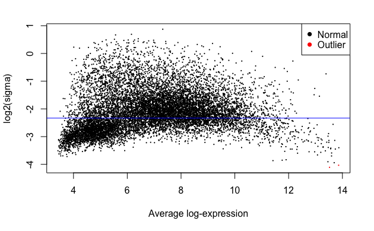

```r
fitLimma <- lmFit(m, design = designLimma)
fitLimma<- eBayes(fitLimma, robust = TRUE, trend = F)
plotSA(fitLimma)
```

```r
summary(decideTests(fitLimma))
```

```
   (Intercept) groupsTGFb batchHesling batchHills batchKeshamouni batchMaupin
-1           0       2683         2282       1337            2020        2808
0            0       6879         1443       1031            1927        1682
1        11900       2338         8175       9532            7953        7410
   batchSun_A549 batchSun_HCC batchSun_NCI batchTaube batchWalsh
-1          2998         2552         2745       1469       9341
0           1446         1313         1444       1334       1244
1           7456         8035         7711       9097       1315
```

Get the test statistics and store DEGs.

```r
statLimma<- topTable(fitLimma, coef = "groupsTGFb", n="inf", sort.by="none")
DEGsLimma<- statLimma[ abs(statLimma$logFC) > 1 &
                         statLimma$adj.P.Val< 0.05, ]
dim(DEGsLimma)  ## 326
```

```
[1] 326   6
```

Look at the heatmap of DEGs.

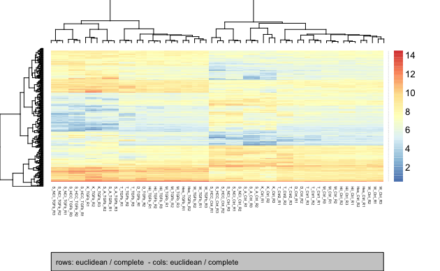

### batch correction using ComBat

The *ComBat()* function can be applied through **sva** package. This function gives you clean data. Many people use the clean data to obtain DEGs through limma; however, you should be carefule because after correction the clean data have new characteristics and may not follow the assumption of limma. specifically, after correction, degrees of freedom would change, and variances of error terms for each gene across samples would not be common.

```
Found 10 batches
Adjusting for 0 covariate(s) or covariate level(s)
Standardizing Data across genes
Fitting L/S model and finding priors
Finding parametric adjustments
Adjusting the Data
```

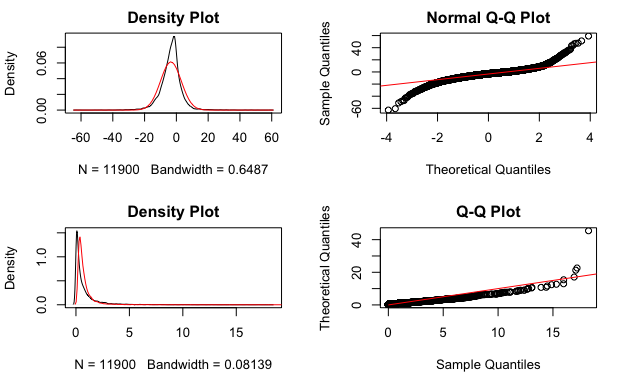

```r
cleanDataComBat<- ComBat(m, batch, designComBat, par.prior=T, prior.plots=T)
```

Look at the RLE plot after correction.

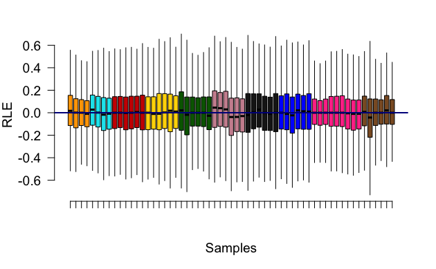

```r
rleComBat<- cleanDataComBat-rowMedians(cleanDataComBat)
boxplot(rleComBat , col= mycols[as.factor(info$study)] ,
          las=2 , cex.axis=1.2 , ylab="RLE" , xlab="Samples" , cex.lab=1.2 ,
          names=FALSE  , frame=F  , whisklty = 1, staplelty = 0 , outline=FALSE )
abline(h=0 , col="darkblue", lwd=2)
```

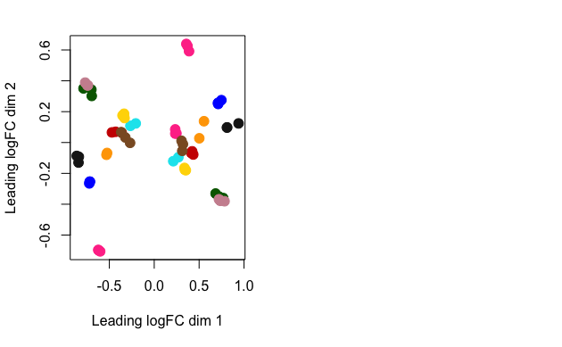

```r
## MDS
par(mfrow=c(1,2))
plotMDS(cleanDataComBat, col= mycols[as.factor(info$study)], pch=19, cex=1.5)
plotMDS(cleanDataComBat, col= mycols[as.factor(info$treatment)], pch=19, cex=1.5)
```

```r
groups<- factor(info$treatment)
# Design matrix based on groups:
designComBat<- model.matrix(~ groups)  # 0:ctrl, 1:TGFb
designComBat
```

```
   (Intercept) groupsTGFb
1            1          0
2            1          1
3            1          0
4            1          1
5            1          0
6            1          1
7            1          0
8            1          1
9            1          0
10           1          0
11           1          0
12           1          1
13           1          1
14           1          1
```

[output cut: 50 more lines]

```r
# fit linear model using limma package:
fitComBat<- lmFit(cleanDataComBat, design= designComBat)
fitComBat<- eBayes(fitComBat, robust = TRUE, trend = F)
# plotSA(fitComBat)
summary(decideTests(fitComBat))
```

```
   (Intercept) groupsTGFb
-1           0       2576
0            0       6967
1        11900       2357
```

Get the test statistics and store DEGs.

```r
statComBat<- topTable(fitComBat, coef = "groupsTGFb", n="inf", sort.by="none")
DEGsComBat<- statComBat[ abs(statComBat$logFC) > 1 &
                           statComBat$adj.P.Val< 0.05, ]
dim(DEGsComBat)  ## 195
```

```
[1] 195   6
```

### Batch correction using SVA

The **sva** package enables us estimate surrogate variables (SVs) and then remove them by including them in the linear model. The *sva()* function estimates the number of SVs. Based on this function, we have 9 SVs. We then add these SVs to the linear model to adjust for them.

```r
groups<- factor(info$treatment)
mod<- model.matrix( ~ groups)
svaFit<- sva(m, mod)   ## 9 significant SVs
```

```
Number of significant surrogate variables is:  9
Iteration (out of 5 ):1  2  3  4  5
```

```r
## add SVs to the model:
designSVA<- model.matrix( ~ groups + svaFit$sv)
fitSVA<- lmFit(as.matrix(m), designSVA)
fitSVA<- eBayes(fitSVA, robust = T, trend = F)
head(fitSVA$coefficients)
```

```
   (Intercept)  groupsTGFb svaFit$sv1 svaFit$sv2 svaFit$sv3 svaFit$sv4 svaFit$sv5
2     4.545003 -0.04253875  -4.018225   3.083259  0.5215782 -0.7432420  0.5265996
9     7.423234 -0.19583376  -6.117342  -1.430846  6.7475006 -0.8498596 -6.3049316
10    4.715674 -0.03159291  -4.269478   1.838032  1.5767523  1.2361441 -0.6681187
12    6.563558 -0.28036415  -4.575123   1.092273  0.4071592 -4.6487911  1.0352834
13    5.452206  0.12428056  -5.719392  -0.918968 -5.6127243 -1.7840373 -9.9786061
14    9.103228 -0.06479240  -5.696129  -2.579255 -0.2496411 -2.3697215  0.7378953
   svaFit$sv6 svaFit$sv7  svaFit$sv8  svaFit$sv9
2    2.179187 -2.7801302  2.07464923  2.13391693
9   -2.798712 -0.3473905 -0.84778401  0.49213848
10   0.507720  0.3220555  1.60758053  0.09239658
12   4.159578 -7.9328934 -1.45609642 -2.93666161
13  -2.740482  2.9001794  2.32284867  0.17531956
14   1.419901 -1.1759855  0.07482129 -1.06995758
```

```r
summary(decideTests(fitSVA))
```

```
   (Intercept) groupsTGFb svaFit$sv1 svaFit$sv2 svaFit$sv3 svaFit$sv4 svaFit$sv5
-1           0       3633      11697       4852       5073       5448       4815
0            0       6068        112       1446       1985       1720       2324
1        11900       2199         91       5602       4842       4732       4761
   svaFit$sv6 svaFit$sv7 svaFit$sv8 svaFit$sv9
-1       4596       5170       4551       4599
0        2672       2338       2611       2636
1        4632       4392       4738       4665
```

Obtain DEGs.

```r
##------- obtaining DEGs:
statSVA<- toptable(fitSVA, coef="groupsTGFb", n="inf", sort.by="none")
DEGsSVA <- statSVA[ abs(statSVA$logFC) > 1 &
                      statSVA$adj.P.Val < 0.05 , ]
dim(DEGsSVA)   ## 322
```

```
[1] 322   5
```

### Batch correcion using RUV

There are several RUV methods for removing unwanted variations in order to obtain DEGs; these include RUV-1, RUV-2, RUV-4, RUV-inv and RUV-rinv. In general, RUV methods are dependent on negative control genes (genes which are not associated with the biological factor of interest) and replicate samples (if applicable). RUV-2 removes unwanted variations in two steps. RUV-4 came after RUV-2 and has four steps. For RUV-4 we need to estimate the number of unwanted variations (k), while for RUV-inv and RUV-rinv we don’t need to estimate k as it is set to be maximum. In general, RUV-inv and RUV-rinv are better than RUV-4. RUV-inv is recommended when we have large number of control genes (~1000), while RUV-rinv is more appropriate with small number of control genes (~60). The negative control genes can be the housekeeping (HK) genes or emprical control genes.  
Here, we only focus on RUV-inv, which is performed by *RUVinv()* function. This function take expression matrix (Y), biological factor of interest (X), and a vector for indices of negative control genes (ctl).  
We load **ruv** package, first, and then we read in the list of HK genes. Using HK genes is not always ideal. that is why we use these HK genes and perform RUV-inv to obtain some statistics, from which we choose genes that are mostly stable across the samples as the *emprical negative control genes*. Then we apply RUV-inv again using these emprical control genes.

```r
# library(ruv)
HKgenes<- read.table("HouseKeeping_genes_IDs.txt", header=T, sep="\t")
hk<- HKgenes$GeneID
mat<- t(m)
mat[1:5,1:5]
```

```
                   2        9       10       12       13
D_Ctrl_R1   4.182898 5.763352 4.467305 8.597186 4.255489
D_TGFb_R1   4.234204 6.063185 4.427406 7.814175 4.317055
D_Ctrl_R2   4.271958 5.698005 4.403148 9.019141 4.235953
D_TGFb_R2   4.221931 5.856127 4.432531 8.458035 4.270769
Hes_Ctrl_R1 6.212082 8.136114 4.746120 9.358340 4.768153
```

```r
ctrl<- colnames(mat) %in% hk
head(ctrl)
```

```
[1] FALSE FALSE FALSE FALSE FALSE  TRUE
```

```r
groups<- factor(info$treatment)  ## take the biological factor of interest
g<- matrix(groups, ncol=1)
g<- as.numeric(as.factor(g))  ## 1 control   2 TGFb
g<- matrix(g, ncol=1)

ruv<- RUVinv(Y=mat, X=g, ctl= ctrl, Z = 1, fullW0 = NULL, lambda = NULL, iterN = 100000)
pvals<- t(ruv$p)
pvals<- data.frame(pvals)
ruv.adj <- variance_adjust(ruv, ebayes = TRUE, evar = TRUE, rsvar = TRUE, bin = 10, rescaleconst = NULL)
adjpvals<- t(ruv.adj$p.BH)
adjpvals<- data.frame(adjpvals)
adjpvals$genes<- row.names(pvals)
adjpvals.ordered <- data.frame(adjpvals[order(adjpvals$adjpvals),])
nGenes<- 0.3 * length(ruv.adj$p.BH)  ## 3570
empCtrl<- tail(adjpvals.ordered$genes, nGenes)
empCtrl<- colnames(mat) %in% empCtrl
```

Use emprical ontrl genes to apply RUV-inv.

```r
ruvEmp<- RUVinv(Y=mat, X=g, ctl=empCtrl, Z = 1, fullW0 = NULL, lambda = NULL, iterN = 100000)
```

Here, we try to obtain test statistics, and select DEGs.

```r
##---- adjust p values:
ruv.adjEmp <- variance_adjust ( ruvEmp, ebayes = TRUE, evar = TRUE, rsvar = TRUE, bin = 10, rescaleconst = NULL)
ruv.adjpvalsEmp <- t(ruv.adjEmp$p.BH)
ruv.adjpvalsEmp<- data.frame(ruv.adjpvalsEmp)
# head(ruv.adjpvalsEmp)
ruv.adjpvalsEmp$genes<- row.names(pvals)
##---- add betahats (logFC) to this:
ruv.adjpvalsEmp$logFC<- t(ruv.adjEmp$betahat)
##---- add t statistics (t) to this:
ruv.adjpvalsEmp$t<- t(ruv.adjEmp$t)
##---- add raw p-values
ruv.adjpvalsEmp$P.Value<- t(ruv.adjEmp$p)
#  export all the p vals and logFCs:
#  write.table(ruv.adjpvalsEmp.ordered, paste0(out_path, method, "_all_adjPvals_logFC_EmpricalCtrl.txt"), sep="\t", row.names=F)
statRUV<- ruv.adjpvalsEmp
rm(ruv.adjpvalsEmp)
## change the col name for adjusted p values so it will be consistent with the other three methods:
colnames(statRUV) [1]<- c("adj.P.Val")
##---------------- obtain DEGs:
DEGsRUV <- statRUV[statRUV$adj.P.Val < 0.05 &
                              abs(statRUV$logFC) >  1 ,]  ##
dim(DEGsRUV)   ## 71 genes
```

```
[1] 71  5
```

### Comparing the results of DE analysis from different batch correction methods.

**1. Compare distribution of p-values.**

```r
par(mfrow=c(2,2))
hist(statLimma$P.Value, breaks=100, col="light blue", main="Limma",
     xlab="p-values")
hist(statComBat$P.Value, breaks=100, col="light blue", main="ComBat",
     xlab="p-values")
```

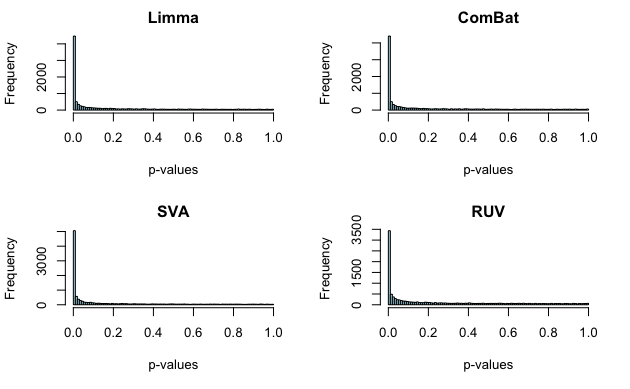

```r
hist(statSVA$P.Value, breaks=100, col="light blue", main="SVA",
     xlab="p-values")
hist(statRUV$P.Value, breaks=100, col="light blue", main="RUV",
     xlab="p-values")
```

**2. Compare volcano plots.**

```r
par(mfrow=c(2,2))
plot(statLimma$logFC, -log10(statLimma$P.Value), cex=0.6,
     main="Limma", xlab="logFC", ylab="-log10(p-value)")
indx<- which(abs(statLimma$logFC) > 1 &
               statLimma$adj.P.Val<0.05)
  points(statLimma$logFC[indx], -log10(statLimma$P.Value[indx]), col="red")
```

```r
  abline(h=-log10(max(statLimma$P.Value[indx])))

plot(statComBat$logFC, -log10(statComBat$P.Value), cex=0.6,
     main="ComBat", xlab="logFC", ylab="-log10(p-value)")
```

```r
indx<- which(abs(statComBat$logFC) > 1 &
                   statComBat$adj.P.Val<0.05)
  points(statComBat$logFC[indx], -log10(statComBat$P.Value[indx]), col="red")
  abline(h=-log10(max(statComBat$P.Value[indx])))
```

```r
plot(statSVA$logFC, -log10(statSVA$P.Value), cex=0.6,
     main="SVA", xlab="logFC", ylab="-log10(p-value)")
indx<- which(abs(statSVA$logFC) > 1 &
                   statSVA$adj.P.Val<0.05)
  points(statSVA$logFC[indx], -log10(statSVA$P.Value[indx]), col="red")
```

```r
  abline(h=-log10(max(statSVA$P.Value[indx])))

plot(statRUV$logFC, -log10(statRUV$P.Value), cex=0.6,
     main="RUV", xlab="logFC", ylab="-log10(p-value)")
```

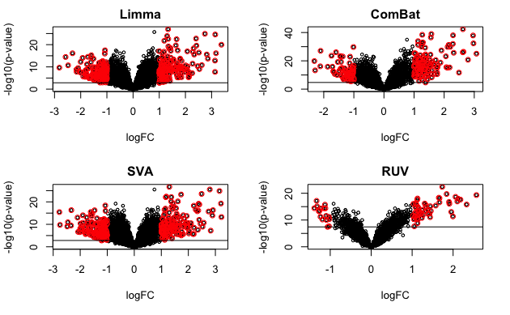

```r
indx<- which(abs(statRUV$logFC) > 1 &
                   statRUV$adj.P.Val<0.05)
  points(statRUV$logFC[indx], -log10(statRUV$P.Value[indx]), col="red")
  abline(h=-log10(max(statRUV$P.Value[indx])))
```

**3. Draw a Venn diagram comparing DEGs**

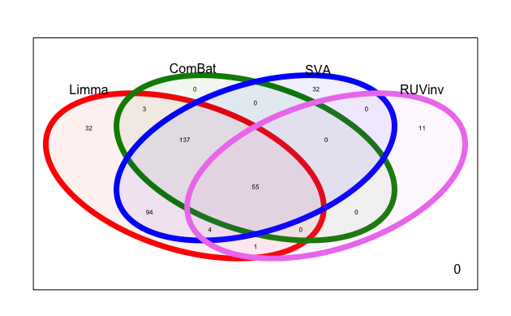